# In class exericse 08

Learning network analysis. Networks are everywhere, it can refer to road maps, urban planning of bus nodes, inter and intra zonal transports, shipping routes, air flight routes, sewerage and water lines, social network

Frostbear https://sg.linkedin.com/in/farahfoo (SMU Masters in IT business (Fintech and Analytics))https://scis.smu.edu.sg/master-it-business  
2022-03-12

# Network Metrics

The network is built using the statistics, to determine the number of nodes, complexity, visual clustering, closeness of the nodes. Between-ness is referring to the importance of the node / concentration risk.

Close-ness means which node is the central that requires the least number of paths to travel from 1 end to the other.

# Examples of network

[figure not shown]

social network by Prof Kam

[figure not shown]

The centrality index is based on the number of flights from one airport to another airport.

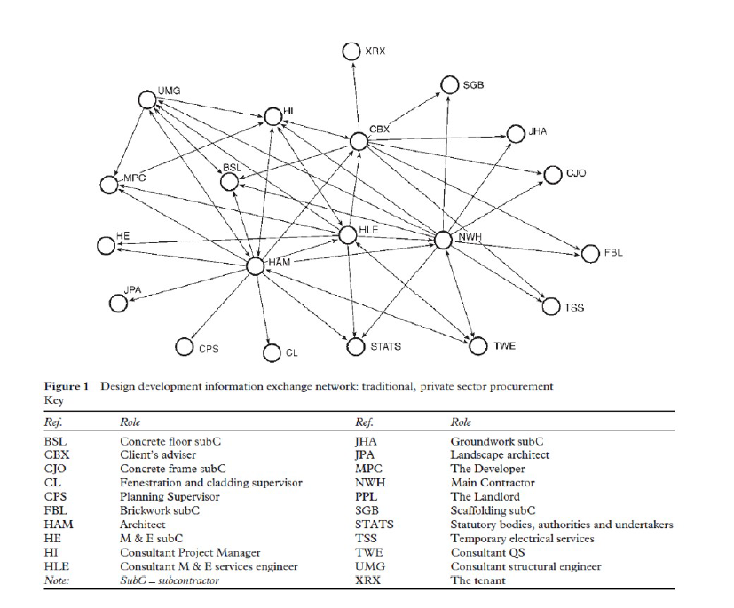

Project management network by Prof Kam

- Bipartite graph - A graph of analysis of executives to reveal the connections between the board of directors
- Neo4j is a noSQL graph database, used to create graphical relational [database.](https://neo4j.com/developer/get-started/)
- [tidygraph](https://www.data-imaginist.com/2017/introducing-tidygraph/) is a Tidy API for graph manipulation.

# Organising the layouts of the network

- Force-directed layouts help to put the layout with equal distance. It is used when all members have the same characteristics.
- Time layouts
- Radial hierarchical layout
- [Geographical layout](https://wiki.smu.edu.sg/1617t3isss608g1/ShinyNET_Data_Prep_Report)
- Tree hierarchical layout - used to map out file path directory
- [Sankey diagram](https://observablehq.com/@d3/sankey) - use to show industry products and different energy use in the UK.

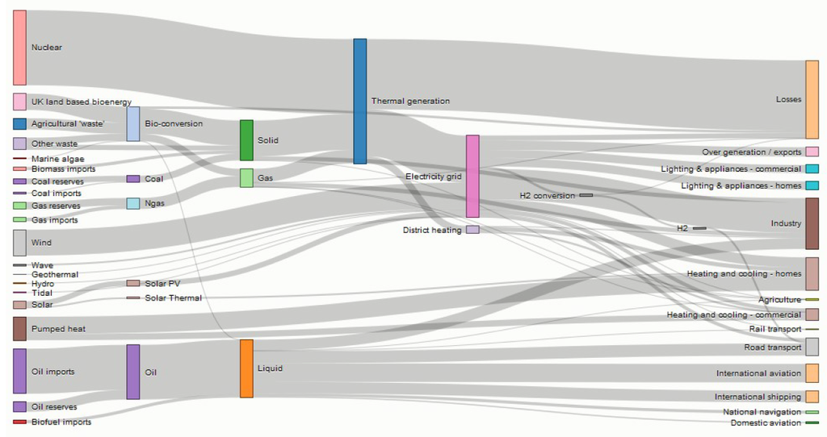

- [Hive plot] (https://konstantinkashin.com/assets/data/hiveplot.html) - very net to show network of individual

# Customisation of parts of the visualisation to represent

Node size, Label, Shapes, Images, Border colour, Weight of line, line colour, line type all can be customised to value-add to the network visualisation.